# Grupo Bimbo Inventory Demand

Maximize sales and minimize returns of bakery goods

Gustavo Moreira

22/07/2019

Este trabalho foi sugerido pela [Data Science Academy](https://www.datascienceacademy.com.br/) durante o curso ‘Formação Cientista de Dados’. Os dados utilizados estão disponíveis na competição [Grupo Bimbo Inventory Demand](https://www.kaggle.com/c/grupo-bimbo-inventory-demand/overview)

# Introdução

O Grupo Bimbo fornece produtos de panificação para diversos clientes em todo o México, atendendo aproximadamente 1 milhão de lojas ao longo de 45.000 rotas diferentes por este país. Atender a demanda adequada para cada loja é um grande desafio, visto que estes produtos possuem um prazo de validade de apenas uma semana, bem como os consumidores desejam comprar produtos frescos.

Há uma linha tênue entre fornecer produtos de menos, resultando em prateleiras vazias, ou fornecer produtos demais, resultando em produtos não vendidos e consequentemente fora do prazo de validade, causando prejuízo financeiro ao o lojista e à empresa. Atualmente os cálculos de inventário são realizados manualmente pelos funcionários responsáveis pelas entregas, que precisam prever a oferta e demanda de cada loja a partir de suas experiências pessoais.

O desafio é propor um modelo de Machine Learning capaz prever a demanda por novos produtos, de forma a maximizar as vendas e minimizar o retorno destes produtos.

# Definindo o problema de negócio

**Objetivo**: Prever a demanda adequada de produtos para cada requisição realizada por cada lojista.

**Observações importantes**:

- É possível que existam requisições para clientes e/ou produtos não documentados anteriormente. O modelo preditivo deve ser capaz de lidar com situações inéditas;
- Existem registros duplicados na tabela de clientes. Será necessário observar estes registros e determinar quais ações devem ser tomadas;

# Observação dos dados disponíveis

```r
input_dir <- '../input'
files <- list.files('../input/', '.csv')

sapply(paste(input_dir, files, sep = '/'), file.info)
```

```
##        ../input/cliente_tabla.csv ../input/producto_tabla.csv
## size   21254426                   109549
## isdir  FALSE                      FALSE
## mode   420                        493
## mtime  1562110737                 1562110737
## ctime  1562146981                 1562146981
## atime  1563927820                 1563927820
## uid    1000                       1000
## gid    1000                       1000
## uname  "gustavo"                  "gustavo"
## grname "gustavo"                  "gustavo"
##        ../input/sample_submission.csv ../input/test.csv
## size   68881421                       251114289
## isdir  FALSE                          FALSE
## mode   420                            493
## mtime  1562110738                     1562110725
## ctime  1562146981                     1562146981
## atime  1563927820                     1563927820
## uid    1000                           1000
## gid    1000                           1000
## uname  "gustavo"                      "gustavo"
## grname "gustavo"                      "gustavo"
##        ../input/town_state.csv ../input/train.csv
## size   29179                   3199358223
## isdir  FALSE                   FALSE
## mode   420                     493
## mtime  1562110737              1562110737
## ctime  1562146981              1562146981
## atime  1563927820              1563927820
## uid    1000                    1000
## gid    1000                    1000
## uname  "gustavo"               "gustavo"
## grname "gustavo"               "gustavo"
```

Foram disponibilizados os seguintes dados:

- cliente_tabla.csv: Tabela com ID e nome de clientes;
- producto_tabla.csv: Tabela com ID e nome de produtos;
- town_state.csv: Tabela com ID e nome de cidades e estados;
- sample_submission: Template de output para testar modelo preditivo no Kaggle;
- test.csv: Dados para teste;
- train.csv: Dados para treino.

```r
datasets = lapply(files, function(x){
  read_csv(paste(input_dir, x, sep = '/'), n_max = 100)
})
```

```r
head(datasets[[1]], 20)
```

```
## # A tibble: 20 x 2
##    Cliente_ID NombreCliente
##         <dbl> <chr>
##  1          0 SIN NOMBRE
##  2          1 OXXO XINANTECATL
##  3          2 SIN NOMBRE
##  4          3 EL MORENO
##  5          4 SDN SER  DE ALIM  CUERPO SA CIA  DE INT
##  6          4 SDN SER DE ALIM CUERPO SA CIA DE INT
##  7          5 LA VAQUITA
##  8          6 LUPITA
##  9          7 I M EL GUERO
## 10          8 MINI SUPER LOS LUPES
## 11          9 SUPER KOMPRAS MICRO COLON
## 12         10 LONJA MERCANTIL DE TODO
## 13         11 FARMACIA NICOLAS SAN JUAN
## 14         12 PAPELERIA CATALA
## 15         13 ELENA
## 16         14 CASA TRINO
## 17         15 FMA035947 BIMBO SA DE CV
## 18         16 JOYS
## 19         17 DE MARCO
## 20         18 LUPES II
```

Observando os primeiros registros, é possível detectar algumas inconsistências:

- O cliente 4 está duplicado;
- Os clientes 0 e 2 possuem o mesmo nome, sugerindo que não podemos agrupar clientes pelo nome dada a possibilidade de existir clientes homônimos.

Será necessário verificar se existe mais de um registro para o mesmo cliente, ou até mesmo um único ID para clientes diferentes.

```r
head(datasets[[2]], 20)
```

```
## # A tibble: 20 x 2
##    Producto_ID NombreProducto
##          <dbl> <chr>
##  1           0 NO IDENTIFICADO 0
##  2           9 Capuccino Moka 750g NES 9
##  3          41 Bimbollos Ext sAjonjoli 6p 480g BIM 41
##  4          53 Burritos Sincro 170g CU LON 53
##  5          72 Div Tira Mini Doradita 4p 45g TR 72
##  6          73 Pan Multigrano Linaza 540g BIM 73
##  7          98 Tostado Integral 180g WON 98
##  8          99 Pan Blanco 567g WON 99
##  9         100 Super Pan Bco Ajonjoli 680g SP WON 100
## 10         106 Wonder 100pct mediano 475g WON 106
## 11         107 Wonder 100pct gde 680g SP WON 107
## 12         108 Baguette Precocida Cong 280g DH 108
## 13         109 Pan Multicereal 475g WON 109
## 14         112 Tostado Integral 180g WON 112
## 15         122 Biscotel Receta Original 410g CU SUA 122
## 16         123 Super Bollos 5in 8p 540g WON 123
## 17         125 Bollos 8p 450g WON 125
## 18         131 Bollos BK 4in 36p 1635g SL 131
## 19         132 Bollos BK 5in 30p 1730g SL 132
## 20         134 Bollos BK 4in 30p 1635g TIR SL 134
```

Os produtos estão corretamente cadastrados. O ID 0 aparenta ser um registro genérico para produtos não identificados previamente.

Cada produto possui informações extras em seu nome, como a quantidade de gramas (567g) e a quantidade de “peças” por pacote (4p). Podemos extrair estes dados para buscar mais características de cada produto.

```r
head(datasets[[5]], 20)
```

```
## # A tibble: 20 x 3
##    Agencia_ID Town                    State
##         <dbl> <chr>                   <chr>
##  1       1110 2008 AG. LAGO FILT      MÉXICO, D.F.
##  2       1111 2002 AG. AZCAPOTZALCO   MÉXICO, D.F.
##  3       1112 2004 AG. CUAUTITLAN     ESTADO DE MÉXICO
##  4       1113 2008 AG. LAGO FILT      MÉXICO, D.F.
##  5       1114 2029 AG.IZTAPALAPA 2    MÉXICO, D.F.
##  6       1116 2011 AG. SAN ANTONIO    MÉXICO, D.F.
##  7       1117 2001 AG. ATIZAPAN       ESTADO DE MÉXICO
##  8       1118 2007 AG. LA VILLA       MÉXICO, D.F.
##  9       1119 2013 AG. MEGA NAUCALPAN ESTADO DE MÉXICO
## 10       1120 2018 AG. TEPALCATES 2   MÉXICO, D.F.
## 11       1121 2016 AG. SAN LORENZO    MÉXICO, D.F.
## 12       1122 2019 AG. XALOSTOC       ESTADO DE MÉXICO
## 13       1123 2094 CHALCO_BM          ESTADO DE MÉXICO
## 14       1124 2021 AG. XOCHIMILCO 2   MÉXICO, D.F.
## 15       1126 2017 AG. SANTA CLARA    ESTADO DE MÉXICO
## 16       1127 2003 AG. COACALCO       ESTADO DE MÉXICO
## 17       1129 2011 AG. SAN ANTONIO    MÉXICO, D.F.
## 18       1130 2010 AG. LOS REYES      ESTADO DE MÉXICO
## 19       1137 2014 AG. NEZA           ESTADO DE MÉXICO
## 20       1138 2015 AG. ROJO GOMEZ     MÉXICO, D.F.
```

Existe um ID primário para cada distribuidora e um ID secundário para cada cidade. Ambos registros estão associados a um estado do México.

```r
head(datasets[[3]], 20)
```

```
## # A tibble: 20 x 2
##       id Demanda_uni_equil
##    <dbl>             <dbl>
##  1     0                 7
##  2     1                 7
##  3     2                 7
##  4     3                 7
##  5     4                 7
##  6     5                 7
##  7     6                 7
##  8     7                 7
##  9     8                 7
## 10     9                 7
## 11    10                 7
## 12    11                 7
## 13    12                 7
## 14    13                 7
## 15    14                 7
## 16    15                 7
## 17    16                 7
## 18    17                 7
## 19    18                 7
## 20    19                 7
```

Template a ser submetido ao Kaggle.

```r
head(datasets[[4]], 20)
```

```
## # A tibble: 20 x 7
##       id Semana Agencia_ID Canal_ID Ruta_SAK Cliente_ID Producto_ID
##    <dbl>  <dbl>      <dbl>    <dbl>    <dbl>      <dbl>       <dbl>
##  1     0     11       4037        1     2209    4639078       35305
##  2     1     11       2237        1     1226    4705135        1238
##  3     2     10       2045        1     2831    4549769       32940
##  4     3     11       1227        1     4448    4717855       43066
##  5     4     11       1219        1     1130     966351        1277
##  6     5     11       1146        4     6601    1741414         972
##  7     6     11       2057        1     4507    4659766        1232
##  8     7     10       1612        1     2837    4414012       35305
##  9     8     10       1349        1     1223     397854        1240
## 10     9     11       1461        1     1203    1646915       43203
## 11    10     11       1124        1     1118    4555688        1278
## 12    11     10       1336        1     1069    4387996        2233
## 13    12     11       1239        1     1125     290608        4270
## 14    13     10       1217        1     1143    4446449        1240
## 15    14     10       1312        1     2056      69110       43274
## 16    15     11       1227        1     2115    1034925       37361
## 17    16     11       2071        1     1203      91580       43200
## 18    17     11       3211        1     1016     325074        1150
## 19    18     10       1629        1     1612    2325923        4270
## 20    19     11      23719        1     2813    4752270       35456
```

Descrição das variáveis disponíveis para teste:

- Semana: Número da semana no ano;
- Agencia_ID: ID da distribuidora, podendo ser associado ao dataset town_state.csv;
- Canal_ID: Meio de comunicação utilizado entre cliente e distribuidora;
- Ruta_SAK: ID do percurso realizado entre a distribuidora e o cliente;
- Cliente_ID: ID do cliente, podendo ser associado ao dataset cliente_tabla.csv;
- Producto_ID: ID do produto, podendo ser associado ao dataset producto_tabla.csv.

```r
head(datasets[[6]], 20)
```

```
## # A tibble: 20 x 11
##    Semana Agencia_ID Canal_ID Ruta_SAK Cliente_ID Producto_ID Venta_uni_hoy
##     <dbl>      <dbl>    <dbl>    <dbl>      <dbl>       <dbl>         <dbl>
##  1      3       1110        7     3301      15766        1212             3
##  2      3       1110        7     3301      15766        1216             4
##  3      3       1110        7     3301      15766        1238             4
##  4      3       1110        7     3301      15766        1240             4
##  5      3       1110        7     3301      15766        1242             3
##  6      3       1110        7     3301      15766        1250             5
##  7      3       1110        7     3301      15766        1309             3
##  8      3       1110        7     3301      15766        3894             6
##  9      3       1110        7     3301      15766        4085             4
## 10      3       1110        7     3301      15766        5310             6
## 11      3       1110        7     3301      15766       30531             8
## 12      3       1110        7     3301      15766       30548             4
## 13      3       1110        7     3301      15766       30571            12
## 14      3       1110        7     3301      15766       31309             7
## 15      3       1110        7     3301      15766       31506            10
## 16      3       1110        7     3301      15766       32393             5
## 17      3       1110        7     3301      15766       32933             3
## 18      3       1110        7     3301      15766       32936             3
## 19      3       1110        7     3301      15766       34053             8
## 20      3       1110        7     3301      15766       35651            12
## # … with 4 more variables: Venta_hoy <dbl>, Dev_uni_proxima <dbl>,
## #   Dev_proxima <dbl>, Demanda_uni_equil <dbl>
```

Além dos dados de teste, temos disponível os valores necessários para calcular as features do modelo preditivo:

- Venta_uni_hoy: Número de vendas nesta semana;
- Venta_hoy: Valor financeiro obtido pelas vendas;
- Dev_uni_proxima: Número de devoluções na próxima semana;
- Dev_proxima: Valor financeiro das devoluções;
- Demanda_uni_equil: Variável a ser prevista, representando a demanda ajustada (Venta_uni_hoy - Dev_uni_proxima).

# Análise exploratória e engenharia de atributos

## Produtos

```r
tbl_products <- read_csv(paste(input_dir, files[2], sep = '/'))
glimpse(tbl_products)
```

```
## Observations: 2,592
## Variables: 2
## $ Producto_ID    <dbl> 0, 9, 41, 53, 72, 73, 98, 99, 100, 106, 107, 108,…
## $ NombreProducto <chr> "NO IDENTIFICADO 0", "Capuccino Moka 750g NES 9",…
```

Cada produto possui algumas informações extras no nome:

- Peso do produto em gramas ou kilogramas e litros ou mililitros;
- Quantidade de peças por unidade.

Podemos extrair estes dados e observar se há correlação entre essas variáveis e a demanda por produtos:

```r
#As informações do peso e unidades de cada produto serão extraídas com Regex
extract_from_product_name <- function(tib){
  pattern_metric_weight <- '\\d+\\s*g|\\d+\\s*kg|\\d+\\s*ml|\\d+\\s*l'
  pattern_numeric_amount <- '\\d+p'
  pattern_product_first_name <- '^\\w+'
  return(tib %>%
           mutate(product_weight = tolower(str_extract(NombreProducto, regex(pattern_metric_weight, ignore_case = T))),
                  product_units = str_extract(NombreProducto, regex(pattern_numeric_amount, ignore_case = T)),
                  product_units = as.numeric(str_extract(product_units, '\\d*')),
                  product_first_name = str_extract(NombreProducto, pattern_product_first_name)))
}

#Função para padronizar o peso do produto em gramas e mililitros
standardize_weight = function(tib){
  metrics = data.frame(measure = c('g', 'kg', 'ml', 'l'),
                       value = c(1, 1000, 1, 1000))

  return(tib %>%
           mutate(measure = str_extract(product_weight, '[:alpha:]+'),
                  product_weight = as.numeric(str_extract(product_weight, '\\d*'))) %>%
           left_join(metrics, by = 'measure') %>%
           mutate(product_weight = product_weight * value) %>%
           select(-measure, -value))
}

#Valores NA na coluna 'product_units' serão substituídos por 1, indicando que o produto é unitário
impute_constant_unit = function(tib){
  return(tib %>% mutate(product_units = replace_na(product_units, 1)))
}

#Valores NA na coluna 'product_weight' serão substituídos pela mediana de seus grupos
impute_group_median_weight = function(tib){

  #Criamos um array com os produtos de valor missing
  na_weight_types <- tib %>%
    filter(is.na(product_weight)) %>%
    group_by(product_first_name) %>%
    summarize %>%
    flatten_chr

  #Para cada grupo, calculamos a mediana de peso de itens semelhantes
  df_median <- tib %>%
    filter(product_first_name %in% na_weight_types) %>%
    group_by(product_first_name) %>%
    summarize(median_weight = median(product_weight, na.rm = T)) %>%
    as.data.frame

  #E então, substituímos os valores NA a partir das medianas calculadas por grupo
  tib_list <- bind_rows(apply(df_median, 1, function(x){
    tib %>%
      filter(product_first_name == x[1]) %>%
      mutate(product_weight = replace_na(product_weight, as.numeric(x[2])))
  }))

  #Colocamos os valores imputados de volta no tibble inicial
  imputed_tbl <- left_join(tib, tib_list, by = 'Producto_ID') %>%
    mutate(product_weight.x = ifelse(is.na(product_weight.x), product_weight.y, product_weight.x)) %>%
    transmute(Producto_ID = Producto_ID,
              NombreProducto = NombreProducto.x,
              product_weight = product_weight.x,
              product_units = product_units.x)
  return(imputed_tbl)
}

#É provável que não seja possível imputar a mediana do peso do grupo em casos específicos, onde não há
#amostras suficientes para calcular a mediana.
#Nessas situações, será imputado o peso médio
impute_mean_weight = function(tib){
  overall_mean_weight = round(mean(tib$product_weight, na.rm = T))
  return(tib %>% mutate(product_weight = replace_na(product_weight, overall_mean_weight)))
}

#Colocamos as etapas em um pipeline
product_pipeline = function(tib){
  steps = extract_from_product_name(tib) %>%
    standardize_weight %>%
    impute_constant_unit %>%
    impute_group_median_weight %>%
    impute_mean_weight
  return(steps)
}
```

```r
tbl_product_info <- product_pipeline(tbl_products)
head(tbl_product_info, 20)
```

```
## # A tibble: 20 x 4
##    Producto_ID NombreProducto                  product_weight product_units
##          <dbl> <chr>                                    <dbl>         <dbl>
##  1           0 NO IDENTIFICADO 0                          429             1
##  2           9 Capuccino Moka 750g NES 9                  750             1
##  3          41 Bimbollos Ext sAjonjoli 6p 480…            480             6
##  4          53 Burritos Sincro 170g CU LON 53             170             1
##  5          72 Div Tira Mini Doradita 4p 45g …             45             4
##  6          73 Pan Multigrano Linaza 540g BIM…            540             1
##  7          98 Tostado Integral 180g WON 98               180             1
##  8          99 Pan Blanco 567g WON 99                     567             1
##  9         100 Super Pan Bco Ajonjoli 680g SP…            680             1
## 10         106 Wonder 100pct mediano 475g WON…            475           100
## 11         107 Wonder 100pct gde 680g SP WON …            680           100
## 12         108 Baguette Precocida Cong 280g D…            280             1
## 13         109 Pan Multicereal 475g WON 109               475             1
## 14         112 Tostado Integral 180g WON 112              180             1
## 15         122 Biscotel Receta Original 410g …            410             1
## 16         123 Super Bollos 5in 8p 540g WON 1…            540             8
## 17         125 Bollos 8p 450g WON 125                     450             8
## 18         131 Bollos BK 4in 36p 1635g SL 131            1635            36
## 19         132 Bollos BK 5in 30p 1730g SL 132            1730            30
## 20         134 Bollos BK 4in 30p 1635g TIR SL…           1635            30
```

## Clientes

```r
tbl_clients <- read_csv(paste(input_dir, files[1], sep = '/'))
glimpse(tbl_clients)
```

```
## Observations: 935,362
## Variables: 2
## $ Cliente_ID    <dbl> 0, 1, 2, 3, 4, 4, 5, 6, 7, 8, 9, 10, 11, 12, 13, 1…
## $ NombreCliente <chr> "SIN NOMBRE", "OXXO XINANTECATL", "SIN NOMBRE", "E…
```

Observando os primeiros registros de clientes, podemos perceber algumas inconsistências:

- Existem registros duplicados, como o ID 4;
- Existem clientes não identificados, cujos nomes foram preenchidos com um valor genérico ‘SIN NOMBRE’ (sem nome).

```r
duplicated_clients <- tbl_clients %>%
  count(Cliente_ID) %>%
  filter(n > 1) %>%
  select(Cliente_ID) %>%
  flatten_dbl
length(duplicated_clients)
```

```
## [1] 4862
```

Dos 935.362 clientes, 4.862 aparecem duplicados. Precisamos verificar se estes registros referem-se ao mesmo cliente cadastrado mais de uma vez ou a clientes distintos compartilhando o mesmo ID:

```r
tbl_duplicated_clients <- tbl_clients %>% filter(Cliente_ID %in% duplicated_clients)

#Utilizaremos regex para 'regularizar' espaços em branco e caracteres especiais, de forma a identificar clientes distintos com IDs iguais
pattern_trim_whitespace = '\\s+'
pattern_replace_punct = '[:punct:]+'
tbl_duplicated_clients <- tbl_duplicated_clients %>%
  mutate(eval_client_name = str_replace_all(NombreCliente, pattern_trim_whitespace, '_'),
         eval_client_name = str_replace_all(eval_client_name, pattern_replace_punct, '_')) %>%
  group_by(Cliente_ID, eval_client_name) %>% summarize %>% ungroup

#Buscando clientes distintos com o mesmo ID
tbl_duplicated_clients %>%
  count(Cliente_ID) %>%
  filter(n > 1) %>%
  select(Cliente_ID) %>%
  left_join(tbl_clients, by = 'Cliente_ID')
```

```
## # A tibble: 2 x 2
##   Cliente_ID NombreCliente
##        <dbl> <chr>
## 1    1646352 SIN NOMBRE
## 2    1646352 LA CHIQUITA
```

Após isolar espaços em branco e caracteres de pontuação do nome, agrupamos os registros por ID e conseguimos identificar quais clientes distintos estão compartilhando o mesmo ID.

Neste caso, foi identificado apenas o cliente ‘LA CHIQUITA’. Como o nome ‘SIN NOMBRE’ está sendo utilizado de forma genérica para denominar clientes não identificados, podemos assumir que os registros duplicados neste dataset referem-se ao mesmo cliente. Portanto, nenhuma ação de regularização será tomada sobre estes dados.

## Cidades

```r
tbl_towns <- read_csv(paste(input_dir, files[5], sep = '/'))
glimpse(tbl_towns)
```

```
## Observations: 790
## Variables: 3
## $ Agencia_ID <dbl> 1110, 1111, 1112, 1113, 1114, 1116, 1117, 1118, 1119,…
## $ Town       <chr> "2008 AG. LAGO FILT", "2002 AG. AZCAPOTZALCO", "2004 …
## $ State      <chr> "MÉXICO, D.F.", "MÉXICO, D.F.", "ESTADO DE MÉXICO", "…
```

As informações de cidades e estados podem ser codificadas e representadas por IDs, a partir dos quais podemos conhecer a demanda média por cidade e estado:

```r
encode_towns = function(tib){
  return(tib %>%
           mutate(Town_ID = as.numeric(factor(Town)),
                  State_ID = as.numeric(factor(State))) %>%
           select(Agencia_ID, Town_ID, State_ID))
}
head(encode_towns(tbl_towns),20)
```

```
## # A tibble: 20 x 3
##    Agencia_ID Town_ID State_ID
##         <dbl>   <dbl>    <dbl>
##  1       1110       6       15
##  2       1111       2       15
##  3       1112       4       10
##  4       1113       6       15
##  5       1114      18       15
##  6       1116       8       15
##  7       1117       1       10
##  8       1118       5       15
##  9       1119       9       10
## 10       1120      14       15
## 11       1121      12       15
## 12       1122      15       10
## 13       1123      50       10
## 14       1124      16       15
## 15       1126      13       10
## 16       1127       3       10
## 17       1129       8       15
## 18       1130       7       10
## 19       1137      10       10
## 20       1138      11       15
```

## Histórico de transações

```r
system('wc -l ../input/train.csv')
```

[output not shown]

Existem cerca de 74 milhões de registros históricos. Serão extraídas aleatoriamente 500.000 amostras de cada semana observada:

```r
tbl_train <- fread(paste(input_dir, files[6], sep = '/'))
week_range <- range(tbl_train$Semana)
week_sequence <- seq(week_range[1], week_range[2], 1)

set.seed(3)
train_sample <- bind_rows(lapply(week_sequence, function(x){
  tbl_train[Semana == x][sample(.N, 500000)]
})) %>% as_tibble
rm(tbl_train)

#Análise estatística
summary(train_sample)
```

```
##      Semana    Agencia_ID       Canal_ID         Ruta_SAK
##  Min.   :3   Min.   : 1110   Min.   : 1.000   Min.   :   1
##  1st Qu.:4   1st Qu.: 1312   1st Qu.: 1.000   1st Qu.:1161
##  Median :6   Median : 1613   Median : 1.000   Median :1285
##  Mean   :6   Mean   : 2536   Mean   : 1.383   Mean   :2113
##  3rd Qu.:8   3rd Qu.: 2036   3rd Qu.: 1.000   3rd Qu.:2802
##  Max.   :9   Max.   :25759   Max.   :11.000   Max.   :9991
##    Cliente_ID         Producto_ID    Venta_uni_hoy        Venta_hoy
##  Min.   :2.600e+01   Min.   :   41   Min.   :   0.000   Min.   :    0.00
##  1st Qu.:3.566e+05   1st Qu.: 1242   1st Qu.:   2.000   1st Qu.:   16.76
##  Median :1.195e+06   Median :30549   Median :   3.000   Median :   30.00
##  Mean   :1.803e+06   Mean   :20833   Mean   :   7.327   Mean   :   68.56
##  3rd Qu.:2.372e+06   3rd Qu.:37374   3rd Qu.:   7.000   3rd Qu.:   56.25
##  Max.   :2.015e+09   Max.   :49996   Max.   :3920.000   Max.   :73367.70
##  Dev_uni_proxima      Dev_proxima        Demanda_uni_equil
##  Min.   :    0.000   Min.   :     0.00   Min.   :   0.000
##  1st Qu.:    0.000   1st Qu.:     0.00   1st Qu.:   2.000
##  Median :    0.000   Median :     0.00   Median :   3.000
##  Mean   :    0.131   Mean   :     1.26   Mean   :   7.241
##  3rd Qu.:    0.000   3rd Qu.:     0.00   3rd Qu.:   6.000
##  Max.   :12760.000   Max.   :102080.00   Max.   :3920.000
```

As informações que temos disponíveis para extrair informações são IDs de diferentes aspectos de cada registro: distribuidora, canal de comunicação, produto solicitado, etc.

Além dos IDs, temos informações sobre a quantidade de vendas e devoluções realizadas. A variável que estamos tentando prever é a “Demanda_uni_equil”, que é calculada da seguinte forma:

$$D = Venta - Devol, D \geqslant 0$$

- $Venta$ = Produtos vendidos na semana (Venta_uni_hoy);
- $Devol$ = Produtos a devolver na semana seguinte (Dev_uni_proxima)

É possível que existam registros em que devoluções superam vendas. Nestes casos, a demanda sempre será igual a zero.

## Visualizações

Para compreender melhor as informações disponíveis, faremos uma série de apresentações combinando a demanda com as demais variáveis.

### Semana

```r
plotdata_semana <- train_sample %>%
  group_by(Semana) %>%
  summarize(sum_venta = sum(Venta_uni_hoy, na.rm = T),
            sum_devol = sum(Dev_uni_proxima, na.rm = T),
            sum_demanda = sum(Demanda_uni_equil, na.rm = T))
```

#### Vendas por semana

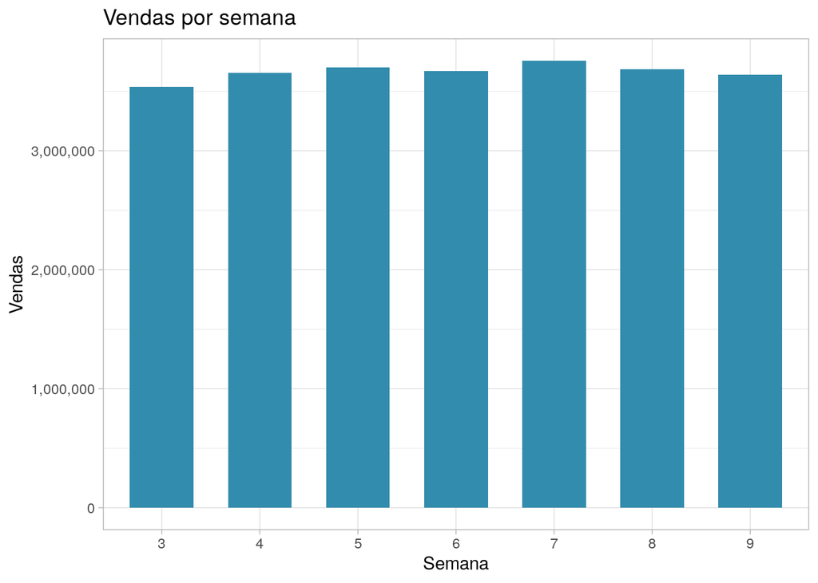

```r
ggplot(data = plotdata_semana) +
  geom_col(mapping = aes(x = as.factor(Semana),
                         y = sum_venta),
           fill = '#328cad', width = 0.65) +
  scale_y_continuous(labels = comma) +
  xlab('Semana') + ylab('Vendas') + theme_light() +
  ggtitle('Vendas por semana')
```

#### Devoluções por semana

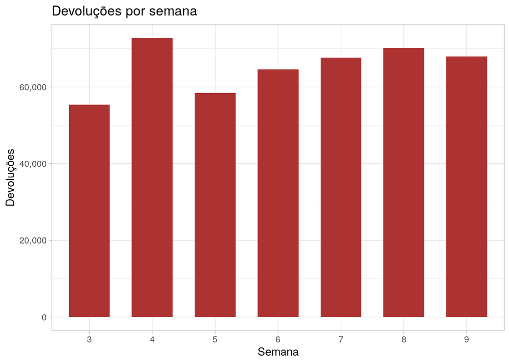

```r
ggplot(data = plotdata_semana) +
  geom_col(mapping = aes(x = as.factor(Semana),
                         y = sum_devol),
           fill = '#ad3232', width = 0.65) +
  scale_y_continuous(labels = comma) +
  xlab('Semana') + ylab('Devoluções') + theme_light() +
  ggtitle('Devoluções por semana')
```

#### Demanda por semana

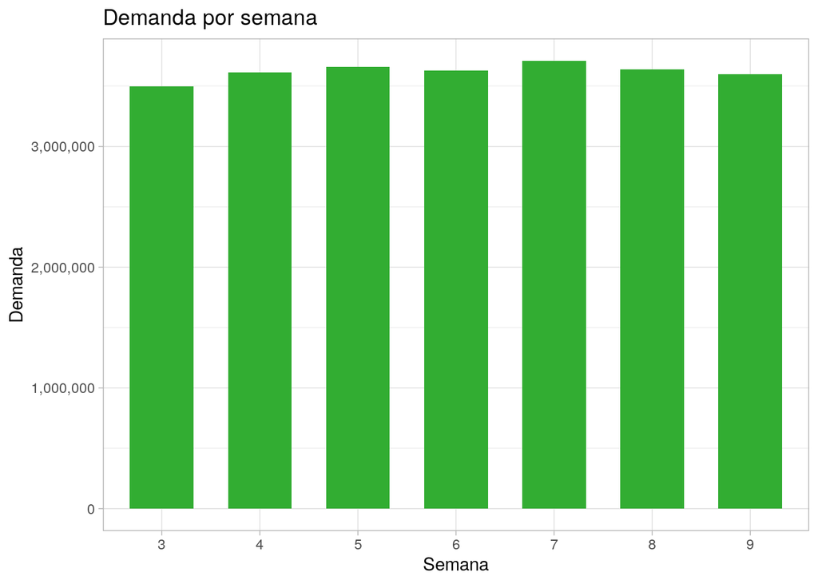

```r
ggplot(data = plotdata_semana) +
  geom_col(mapping = aes(x = as.factor(Semana),
                         y = sum_demanda),
           fill = '#32ad32', width = 0.65) +
  scale_y_continuous(labels = comma) +
  xlab('Semana') + ylab('Demanda') + theme_light() +
  ggtitle('Demanda por semana')
```

- Nos dados observados, não há variação suficiente na demanda semanal para justificar o uso dessa variável.
- É possível observar um aumento no volume de devoluções a cada 4 semanas, sugerindo que exista um padrão comportamental periódico dos clientes.

### Canal

```r
plotdata_channel <- train_sample %>%
  count(Canal_ID, name = 'count_channel') %>%
  mutate(prop = (count_channel / sum(count_channel)) * 100)
```

#### Registros por canal

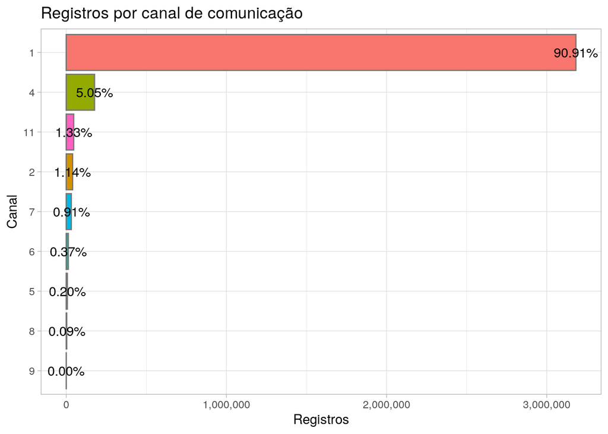

```r
ggplot(data = plotdata_channel,
       mapping = aes(x = reorder(as.factor(Canal_ID), count_channel),
                     y = count_channel,
                     fill = as.factor(Canal_ID))) +
  geom_col(color = '#777777', show.legend = F) +
  geom_text(mapping = aes(label = sprintf('%.2f%%', prop))) +
  scale_y_continuous(labels = comma) +
  coord_flip() + theme_light() +
  xlab('Canal') + ylab('Registros') +
  ggtitle('Registros por canal de comunicação')
```

90.9% das requisições são realizadas pelo canal 1, seguido pelo canal 4 com 5% das requisições. Os demais canais de comunicação concentram menos de 2% das requisições realizadas.

Após conhecer a proporção de uso destes canais, observamos a demanda média de cada registro.

#### Demanda por canal

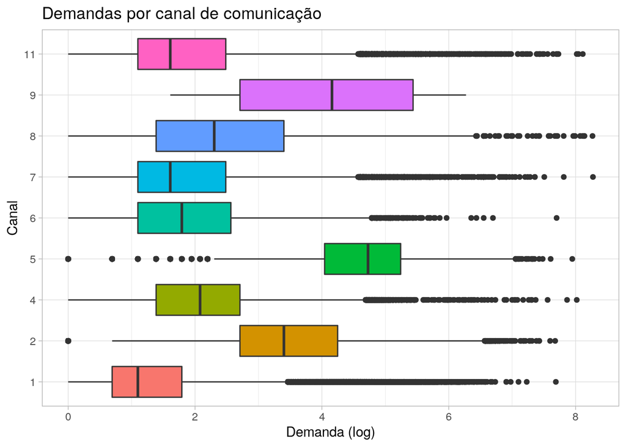

```r
ggplot(data = train_sample %>% filter(Demanda_uni_equil > 0)) +
  geom_boxplot(mapping = aes(x = as.factor(Canal_ID),
                             y = log(Demanda_uni_equil),
                             fill = as.factor(Canal_ID)),
               show.legend = F) +
  coord_flip() + theme_light() +
  xlab('Canal') + ylab('Demanda (log)') +
  ggtitle('Demandas por canal de comunicação')
```

- Este gráfico sugere que, em média, as demandas mais volumosas são atendidas pelos canais 5, 9 e 2. Contudo, no gráfico anterior, percebemos que estes canais são pouco utilizados;
- Mais importante, é possível detectar outliers de escala semelhante em todos canais de comunicação, sugerindo que não há uma distinção entre a demanda e o canal de comunicação.

### Distribuidora

```r
plotdata_depot <- train_sample %>%
  group_by(Agencia_ID) %>%
  summarize(mean_depot_demanda = mean(Demanda_uni_equil),
            sum_depot_demanda = sum(Demanda_uni_equil)) %>%
  left_join(train_sample %>% count(Agencia_ID, name = 'count_agencia'), by = 'Agencia_ID') %>%
  left_join(encode_towns(tbl_towns), by = 'Agencia_ID')
```

#### Proporção de demanda por registro de distribuidora

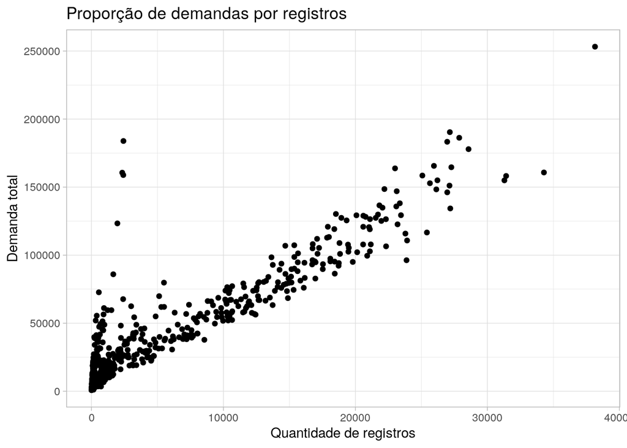

```r
ggplot(data = plotdata_depot,
       mapping = aes(x = count_agencia,
                     y = sum_depot_demanda)) + geom_point() +
  xlab('Quantidade de registros') + ylab('Demanda total') + theme_light() +
  ggtitle('Proporção de demandas por registros')
```

Quando comparamos o total de demanda com a quantidade de registros, é esperada que exista uma correlação positiva (quanto mais registros atendidos, maior a demanda total). Contudo, este gráfico nos auxilia a encontrar alguns outliers do lado esquerdo: depósitos com baixo volume de registros e alto volume de demanda.

Podemos classificar estes registros como “distribuidoras de larga escala”, sugerindo que registros efetuados para estas distribuidoras costumam resultar em alta demanda. Para isso, definimos um limiar de demanda média e quantidade média de registros atendidos:

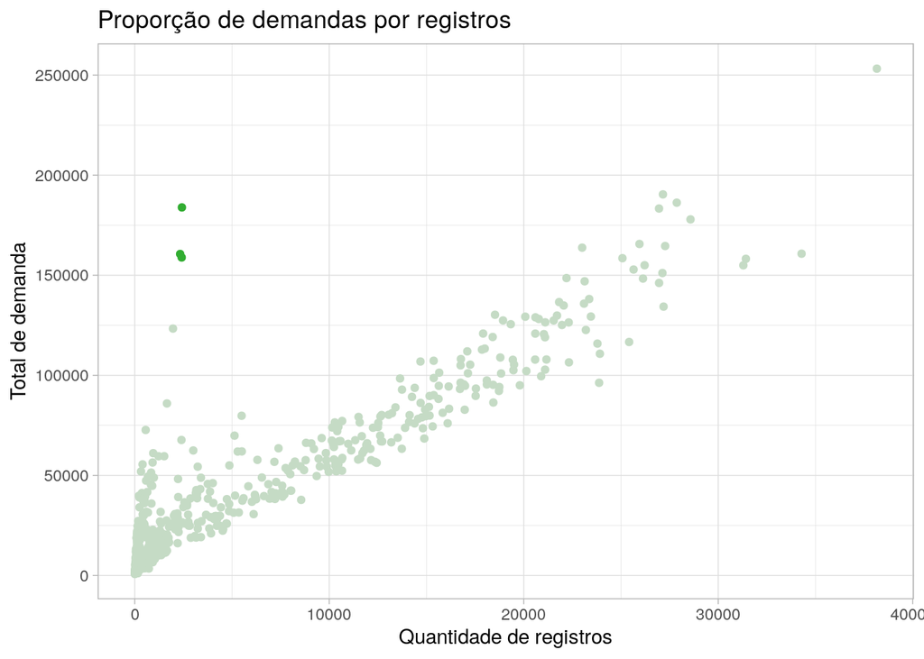

```r
large_scale_depot_mean_threshold = quantile(plotdata_depot$mean_depot_demanda, 0.75)
large_scale_depot_count_threshold = quantile(plotdata_depot$count_agencia, 0.5)

plotdata_depot <- plotdata_depot %>%
  mutate(large_scale_depot = as.numeric(mean_depot_demanda >= large_scale_depot_mean_threshold &
                                          count_agencia >= large_scale_depot_count_threshold))

ggplot(data = plotdata_depot,
       mapping = aes(x = count_agencia,
                     y = sum_depot_demanda)) +
  geom_point(mapping = aes(color = as.factor(large_scale_depot)),
             show.legend = F) +
  scale_color_manual(values = c('#c5dbc5', '#32ad32')) +
  xlab('Quantidade de registros') + ylab('Total de demanda') + theme_light() +
  ggtitle('Proporção de demandas por registros')
```

```r
plotdata_depot %>%
  filter(large_scale_depot == 1) %>%
  arrange(-mean_depot_demanda)
```

```
## # A tibble: 3 x 7
##   Agencia_ID mean_depot_dema… sum_depot_deman… count_agencia Town_ID
##        <dbl>            <dbl>            <int>         <int>   <dbl>
## 1       1129             75.9           183893          2424       8
## 2       1114             68.8           160623          2334      18
## 3       1142             65.8           158888          2413       9
## # … with 2 more variables: State_ID <dbl>, large_scale_depot <dbl>
```

Em média, é esperado que as solicitações realizadas para estas distribuidoras sejam maiores que o usual.

### Cidade

```r
plotdata_town <- plotdata_depot %>%
  select(sum_depot_demanda, count_agencia, Town_ID) %>%
  group_by(Town_ID) %>%
  summarize(sum_town_demanda = sum(sum_depot_demanda),
            count_town_demanda = sum(count_agencia),
            mean_town_demanda = sum_town_demanda/count_town_demanda) %>% ungroup
```

#### Demanda total por cidade

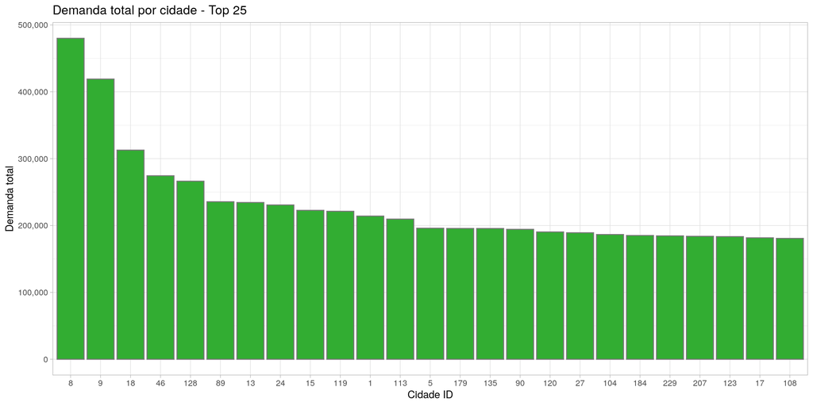

```r
ggplot(data = plotdata_town %>% top_n(25, sum_town_demanda),
       mapping = aes(x = reorder(as.factor(Town_ID), -sum_town_demanda),
                     y = sum_town_demanda)) +
  geom_col(color = '#777777', fill = '#32ad32') +
  scale_y_continuous(labels = comma) + theme_light() +
  xlab('Cidade ID') + ylab('Demanda total') +
  ggtitle('Demanda total por cidade - Top 25')
```

#### Demanda total e quantidade de distribuidoras por cidade

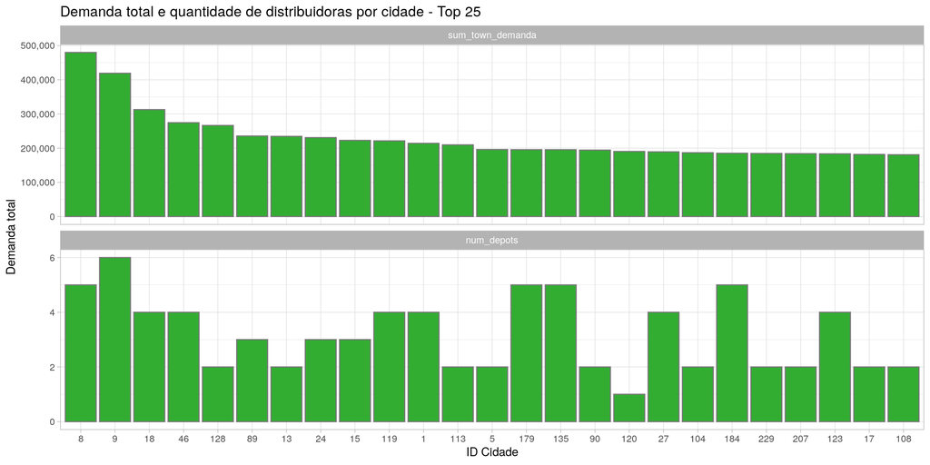

```r
depots_by_town <- plotdata_depot %>%
  count(Town_ID, name = 'num_depots')

ggplot(data = plotdata_town %>%
         top_n(25, sum_town_demanda) %>%
         left_join(depots_by_town, by = 'Town_ID') %>%
         select(Town_ID, sum_town_demanda, num_depots) %>% melt(id = 'Town_ID'),
       mapping = aes(x = reorder(as.factor(Town_ID), -value),
                     y = value)) +
  geom_col(color = '#777777', fill = '#32ad32') +
  scale_y_continuous(labels = comma) + theme_light() +
  facet_wrap(facets = ~ variable,
             scales = 'free_y',
             nrow = 2, ncol = 1) +
  xlab('ID Cidade') + ylab('Demanda total') +
  ggtitle('Demanda total e quantidade de distribuidoras por cidade - Top 25')
```

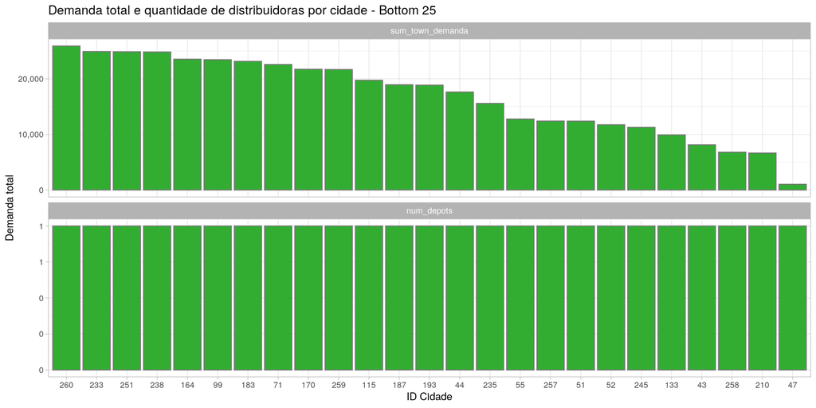

```r
ggplot(data = plotdata_town %>%
         top_n(-25, sum_town_demanda) %>%
         left_join(depots_by_town, by = 'Town_ID') %>%
         select(Town_ID, sum_town_demanda, num_depots) %>% melt(id = 'Town_ID'),
       mapping = aes(x = reorder(as.factor(Town_ID), -value),
                     y = value)) +
  geom_col(color = '#777777', fill = '#32ad32') +
  scale_y_continuous(labels = comma) + theme_light() +
  facet_wrap(facets = ~ variable,
             scales = 'free_y',
             nrow = 2, ncol = 1) +
  xlab('ID Cidade') + ylab('Demanda total') +
  ggtitle('Demanda total e quantidade de distribuidoras por cidade - Bottom 25')
```

Existe uma correlação entre a demanda por cidade e a quantidade de distribuidoras disponíveis. Cidades com maior demanda possuem mais distribuidoras, enquanto cidades com menor demanda possuem menos distribuidoras.

### Cliente

```r
plotdata_client <- train_sample %>%
  group_by(Cliente_ID) %>%
  summarize(mean_demanda_cliente = mean(Demanda_uni_equil),
            sum_demanda_cliente = sum(Demanda_uni_equil)) %>%
  left_join(tbl_clients, by = 'Cliente_ID')
```

#### Demanda média e demanda total por cliente

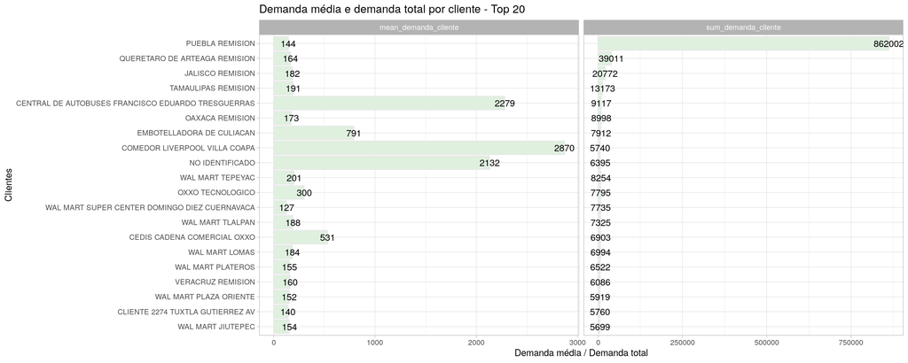

```r
ggplot(data = plotdata_client %>%
         top_n(20, sum_demanda_cliente) %>%
         select(-Cliente_ID) %>% melt(id = 'NombreCliente'),
       mapping = aes(x = reorder(as.factor(NombreCliente), value),
                     y = value)) +
  geom_col(color = '#e7e7e7', fill = '#dff0df') +
  geom_text(mapping = aes(label = sprintf('%.0f', value))) +
  coord_flip() + theme_light() +
  facet_wrap(facets = ~ variable,
             scales = 'free_x',
             nrow = 1, ncol = 2) +
  xlab('Clientes') + ylab('Demanda média / Demanda total') +
  ggtitle('Demanda média e demanda total por cliente - Top 20')
```

Puebla Remision é um dos principais clientes do Grupo Bimbo, com aproximadamente 860.000 produtos vendidos neste conjunto de dados, valor muito superior aos demais clientes.

Mesmo com essa presença excessiva, a demanda média deste cliente está bem próxima aos demais registros, ao passo que outros clientes possuem uma demanda média muito elevada, mas pouca demanda total registrada.

Uma possível justificativa para essa discrepância é a variedade de produtos vendidos. É possível que clientes com baixa variedade de produtos necessitam de um volume maior destes itens, enquanto clientes com uma variedade maior demandam uma quantidade menor de cada item.

### Produto

```r
plotdata_product <- train_sample %>%
  group_by(Producto_ID) %>%
  summarize(mean_producto_demanda = mean(Demanda_uni_equil),
            sum_producto_demanda = sum(Demanda_uni_equil)) %>%
  left_join(product_pipeline(tbl_products), by = 'Producto_ID')
```

#### Demanda média por peso do produto

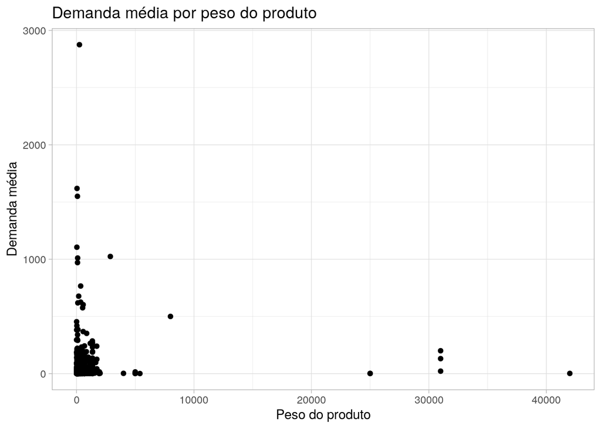

```r
ggplot(data = plotdata_product,
       mapping = aes(x = product_weight,
                     y = mean_producto_demanda)) +
  geom_point() + theme_light() +
  xlab('Peso do produto') + ylab('Demanda média') +
  ggtitle('Demanda média por peso do produto')
```

Na maioria das ocorrências, não há uma correlação entre a demanda e o peso do produto. Contudo, é possível perceber que produtos mais pesados possuem uma demanda menor, enquanto produtos mais leves possuem uma demanda maior.

#### Demanda média por variedade de produtos por cliente

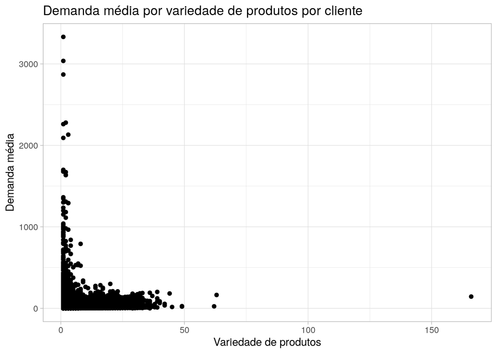

```r
product_by_client <- train_sample %>%
  group_by(Cliente_ID) %>%
  summarize(unique_product_count = n_distinct(Producto_ID))

ggplot(data = product_by_client %>% right_join(plotdata_client, by = 'Cliente_ID'),
       mapping = aes(x = unique_product_count,
                     y = mean_demanda_cliente)) +
  geom_point() + theme_light() +
  xlab('Variedade de produtos') + ylab('Demanda média') +
  ggtitle('Demanda média por variedade de produtos por cliente')
```

Semelhante ao observado em relação ao peso do produto, não há uma correlação direta entre essas duas variáveis, porém é esperado uma demanda média menor à medida que produtos diferentes são solicitados pelo cliente.

# Concepção do modelo preditivo

A partir das observações realizadas durante análise, decidi selecionar as seguintes features para compor o modelo preditivo:

- Demanda média por cliente;
- Demanda média por produto;
- Demanda média por cidade;
- Demanda média por distribuidora.

As médias serão calculadas em escala logarítmica. Além destas, também serão adicionadas features binárias:

- Distribuidora de larga escala;
- Produto é pesado ($p \geqslant 5000g$);
- Produto possui múltiplas unidades ($u \geqslant 6$).

```r
#Extrair métricas a partir do nome do produto
extract_from_product_name <- function(tib){
  pattern_metric_weight <- '\\d+\\s*g|\\d+\\s*kg|\\d+\\s*ml|\\d+\\s*l'
  pattern_numeric_amount <- '\\d+p'
  pattern_product_first_name <- '^\\w+'
  return(tib %>%
           mutate(product_weight = tolower(str_extract(NombreProducto, regex(pattern_metric_weight, ignore_case = T))),
                  product_units = str_extract(NombreProducto, regex(pattern_numeric_amount, ignore_case = T)),
                  product_units = as.numeric(str_extract(product_units, '\\d*')),
                  product_first_name = str_extract(NombreProducto, pattern_product_first_name)))
}

#Padronização de peso por produto
standardize_weight = function(tib){
  metrics = data.frame(measure = c('g', 'kg', 'ml', 'l'),
                       value = c(1, 1000, 1, 1000))

  return(tib %>%
           mutate(measure = str_extract(product_weight, '[:alpha:]+'),
                  product_weight = as.numeric(str_extract(product_weight, '\\d*'))) %>%
           left_join(metrics, by = 'measure') %>%
           mutate(product_weight = product_weight * value) %>%
           select(-measure, -value))
}

#Imputar valor constante na quantidade unitária de produtos
impute_constant_unit = function(tib){
  return(tib %>% mutate(product_units = replace_na(product_units, 1)))
}

#Imputar mediana no peso por grupo de produto
impute_group_median_weight = function(tib){

  #Criamos um array com os produtos de valor missing
  na_weight_types <- tib %>%
    filter(is.na(product_weight)) %>%
    group_by(product_first_name) %>%
    summarize %>%
    flatten_chr

  #Para cada grupo, calculamos a mediana de peso de itens semelhantes
  df_median <- tib %>%
    filter(product_first_name %in% na_weight_types) %>%
    group_by(product_first_name) %>%
    summarize(median_weight = median(product_weight, na.rm = T)) %>%
    as.data.frame

  #E então, substituímos os valores NA a partir das medianas calculadas por grupo
  tib_list <- bind_rows(apply(df_median, 1, function(x){
    tib %>%
      filter(product_first_name == x[1]) %>%
      mutate(product_weight = replace_na(product_weight, as.numeric(x[2])))
  }))

  #Colocamos os valores imputados de volta no tibble inicial
  imputed_tbl <- left_join(tib, tib_list, by = 'Producto_ID') %>%
    mutate(product_weight.x = ifelse(is.na(product_weight.x), product_weight.y, product_weight.x)) %>%
    transmute(Producto_ID = Producto_ID,
              NombreProducto = NombreProducto.x,
              product_weight = product_weight.x,
              product_units = product_units.x)
  return(imputed_tbl)
}

#Imputar média no peso do produto
impute_mean_weight = function(tib){
  overall_mean_weight = round(mean(tib$product_weight, na.rm = T))
  return(tib %>% mutate(product_weight = replace_na(product_weight, overall_mean_weight)))
}

#Calcular as features de produtos
calc_product_features = function(tib){

  #Produtos acima de 5 litros ou 5 kilogramas serão classificados como "produtos pesados"
  weight_threshold = 5000

  #Produtos com 6 ou mais unidades serão classificados como "produtos empacotados"
  bundle_threshold = 6

  return(tib %>%
           mutate(heavy_product = as.numeric(product_weight >= weight_threshold),
                  bundled_product = as.numeric(product_units >= 6)))
}

#Pipeline de produtos
product_pipeline = function(tib){
  steps = extract_from_product_name(tib) %>%
    standardize_weight %>%
    impute_constant_unit %>%
    impute_group_median_weight %>%
    impute_mean_weight %>%
    calc_product_features
  return(steps)
}

#### Cidades ####
#Aplicar label encoding nas cidades e estados
encode_towns = function(tib){
  return(tib %>%
           mutate(Town_ID = as.numeric(factor(Town)),
                  State_ID = as.numeric(factor(State))) %>%
           select(Agencia_ID, Town_ID, State_ID))
}

#### Feature Engineering ####
calc_train_features = function(train_data, product_data, town_data,
                               quantile_depot_mean_threshold = 0.75,
                               quantile_depot_count_threshold = 0.5){

  #Produtos
  product_info = product_pipeline(product_data) %>%
    select(-NombreProducto, -product_weight, -product_units)

  #Cidades
  town_info = encode_towns(town_data)

  #Demanda por canal
  channels = train_data %>%
    group_by(Canal_ID) %>%
    summarize(mean_channel_demanda = mean(Demanda_uni_equil, na.rm = T)) %>% ungroup

  #Demanda por distribuidoras
  depots = train_data %>%
    group_by(Agencia_ID) %>%
    summarize(mean_depot_demanda = mean(Demanda_uni_equil)) %>%
    left_join(train_data %>% count(Agencia_ID, name = 'count_agencia'), by = 'Agencia_ID') %>%
    left_join(town_info, by = 'Agencia_ID')

  large_scale_depot_mean_threshold = quantile(depots$mean_depot_demanda, quantile_depot_mean_threshold)
  large_scale_depot_count_threshold = quantile(depots$count_agencia, quantile_depot_count_threshold)

  depots <- depots %>%
    mutate(large_scale_depot = as.numeric(mean_depot_demanda >= large_scale_depot_mean_threshold &
                                            count_agencia >= large_scale_depot_count_threshold)) %>%
    select(-count_agencia)

  #Demanda por cidade
  town_depots = train_data %>%
    left_join(town_info, by = 'Agencia_ID') %>%
    group_by(Town_ID) %>%
    summarize(mean_town_demanda = mean(Demanda_uni_equil))

  #Demanda por cliente
  clients = train_data %>%
    group_by(Cliente_ID) %>%
    summarize(mean_demanda_cliente = mean(Demanda_uni_equil)) %>%
    distinct

  #Demanda por produto
  products = train_data %>%
    group_by(Producto_ID) %>%
    summarize(mean_producto_demanda = mean(Demanda_uni_equil)) %>%
    left_join(product_info, by = 'Producto_ID')

  return(list(channels, depots, town_depots, clients, products))
}
```

## Carregando os dados de treino

```r
input_dir = '../input'

#Selecionando arquivos
files <- list.files(input_dir, '.csv')

#Produtos
tbl_products <- read_csv(paste(input_dir, files[2], sep = '/'))

#Cidades
tbl_towns <- read_csv(paste(input_dir, files[5], sep = '/'))

#Dados de treino
tbl_train <- fread(paste(input_dir, files[6], sep = '/'), select = c('Semana', 'Agencia_ID', 'Canal_ID', 'Cliente_ID', 'Producto_ID', 'Demanda_uni_equil'))

#Colocando a demanda em escala logarítmica
tbl_train[, Demanda_uni_equil := log1p(Demanda_uni_equil)]

#Serão selecionados 500.000 registros das semanas 5, 6, 7 e 8
set.seed(11)
train_sample <- bind_rows(lapply(5:8, function(x){
  tbl_train[Semana == x][sample(.N, 500000)]
})) %>% as_tibble

#Removemos o dataset completo para reduzir o espaço utilizado em memória
rm(tbl_train)

#Calculamos as features
features = calc_train_features(train_sample, tbl_products, tbl_towns)

#Agrupando features
for(f in features){
  train_sample <- train_sample %>% left_join(f)
}

#Retirando variáveis não utilizadas
train_sample <- train_sample %>%
  select(-Semana, -Agencia_ID, -Canal_ID, -Producto_ID, -Cliente_ID, -Town_ID, -State_ID)

#Será utilizado um modelo de regressão linear múltipla. O modelo será treinado com dados
#entre 1.5 desvios padrões da média
mean_threshold <- mean(train_sample$Demanda_uni_equil)
sd_threshold <- sd(train_sample$Demanda_uni_equil)

train_sample <- train_sample %>%
  filter(Demanda_uni_equil >= mean_threshold - (1.5 * sd_threshold) &
         Demanda_uni_equil <= mean_threshold + (1.5 * sd_threshold))
```

## Criação do modelo

Serão utilizados dois modelos preditivos, regressão linear múltipla (lm) e gradiente estocástico descendente (gbm):

```r
set.seed(17)
t_index = createDataPartition(train_sample$Demanda_uni_equil, times = 1, p = 0.7, list = F)
train = train_sample[t_index,]
test = train_sample[-t_index,]

model_lm <- lm(Demanda_uni_equil ~ ., data = train)
summary(model_lm)
```

```
##
## Call:
## lm(formula = Demanda_uni_equil ~ ., data = train)
##
## Residuals:
##     Min      1Q  Median      3Q     Max
## -3.6849 -0.2843 -0.0182  0.2724  1.9201
##
## Coefficients:
##                         Estimate Std. Error t value Pr(>|t|)
## (Intercept)           -0.2660014  0.0052542 -50.627  < 2e-16 ***
## mean_channel_demanda  -0.1850983  0.0040483 -45.723  < 2e-16 ***
## mean_depot_demanda    -0.0047852  0.0046219  -1.035  0.30051
## large_scale_depot     -0.4833400  0.0186516 -25.914  < 2e-16 ***
## mean_town_demanda      0.0787418  0.0037932  20.759  < 2e-16 ***
## mean_demanda_cliente   0.6614549  0.0009093 727.417  < 2e-16 ***
## mean_producto_demanda  0.5805853  0.0009945 583.814  < 2e-16 ***
## heavy_product         -0.0660731  0.0201756  -3.275  0.00106 **
## bundled_product       -0.0194679  0.0008977 -21.687  < 2e-16 ***
## ---
## Signif. codes:  0 '***' 0.001 '**' 0.01 '*' 0.05 '.' 0.1 ' ' 1
##
## Residual standard error: 0.4312 on 1261488 degrees of freedom
## Multiple R-squared:  0.4652, Adjusted R-squared:  0.4652
## F-statistic: 1.372e+05 on 8 and 1261488 DF,  p-value: < 2.2e-16
```

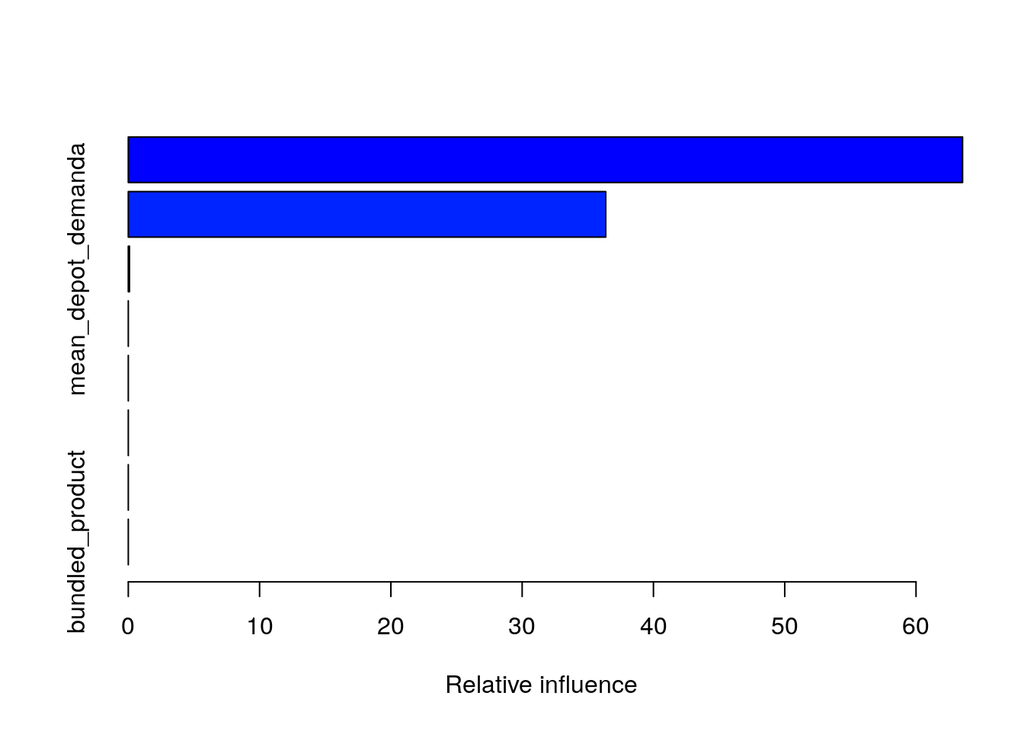

```
##                                         var     rel.inf
## mean_demanda_cliente   mean_demanda_cliente 63.54532422
## mean_producto_demanda mean_producto_demanda 36.36622876
## mean_depot_demanda       mean_depot_demanda  0.08844702
## mean_channel_demanda   mean_channel_demanda  0.00000000
## large_scale_depot         large_scale_depot  0.00000000
## mean_town_demanda         mean_town_demanda  0.00000000
## heavy_product                 heavy_product  0.00000000
## bundled_product             bundled_product  0.00000000
```

```r
gbm_tuneGrid = expand.grid(n.trees = c(10, 20, 30),
                           interaction.depth = 1,
                           shrinkage = c(0.1, 1),
                           n.minobsinnode = 100)
gbm_trControl = trainControl(number = 1, search = 'grid', verboseIter = F)
model_gbm = train(Demanda_uni_equil ~ .,
                  data = train,
                  method = 'gbm',
                  tuneGrid = gbm_tuneGrid,
                  trControl = gbm_trControl)
summary(model_gbm)
```

Este modelo sofreu uma influência muito significativa da média por cliente e a média por produto, sugerindo que o uso dessas duas variáveis resultará em um modelo tendencioso e com baixa capacidade de generalização, especialmente se utilizado para realizar previsões sobre um cliente ou produto deconhecidos.

## Teste do modelo

Com os modelos criados, realizamos previsões nos dados de teste e avaliamos a performance utilizando a métrica RMSLE:

```r
#Como a demanda sempre será um valor maior ou igual a zero, valores negativos serão substituídos por zero
preds_lm <- predict.lm(model_lm, test)
preds_lm <- replace(preds_lm, preds_lm < 0, 0)
RMSLE(preds_lm, test$Demanda_uni_equil)
```

```
## [1] 0.1740643
```

```r
preds_gbm <- predict.train(model_gbm, test)
preds_gbm <- replace(preds_gbm, preds_gbm < 0, 0)
RMSLE(preds_gbm, test$Demanda_uni_equil)
```

```
## [1] 0.1742186
```

Os dois modelos apresentaram performances semelhantes neste conjunto de dados. Faremos uma avaliação final utilizando os dados de teste da competição.

## Submetendo resultados ao Kaggle

```r
kaggle_test_data = fread(paste(input_dir, files[4], sep = '/'))
kaggle_test_data <- merge(kaggle_test_data, features[[1]], all.x = T, by = 'Canal_ID')
kaggle_test_data <- merge(kaggle_test_data, features[[2]], all.x = T, by = 'Agencia_ID')
kaggle_test_data <- merge(kaggle_test_data, features[[3]], all.x = T, by = 'Town_ID')
kaggle_test_data <- merge(kaggle_test_data, features[[4]], all.x = T, by = 'Cliente_ID')
kaggle_test_data <- merge(kaggle_test_data, features[[5]], all.x = T, by = 'Producto_ID')

#Verificando valores NA
sapply(kaggle_test_data, function(x) sum(is.na(x)))

#Nas features relacionadas a médias já calculadas, será imputada a mediana.
#Nas demais features binárias, será imputado um valor constante zero
kaggle_test_data[is.na(mean_depot_demanda)]$mean_depot_demanda <- median(kaggle_test_data$mean_depot_demanda, na.rm = T)
kaggle_test_data[is.na(mean_town_demanda)]$mean_town_demanda <- median(kaggle_test_data$mean_town_demanda, na.rm = T)
kaggle_test_data[is.na(mean_demanda_cliente)]$mean_demanda_cliente <- median(kaggle_test_data$mean_demanda_cliente, na.rm = T)
kaggle_test_data[is.na(mean_producto_demanda)]$mean_producto_demanda <- median(kaggle_test_data$mean_producto_demanda, na.rm = T)
kaggle_test_data[is.na(large_scale_depot)]$large_scale_depot <- 0
kaggle_test_data[is.na(heavy_product)]$heavy_product <- 0
kaggle_test_data[is.na(bundled_product)]$bundled_product <- 0

submission_preds_lm <- predict.lm(model_lm, kaggle_test_data)
submission_preds_lm <- replace(submission_preds_lm, submission_preds_lm < 0, 0)

submission_preds_gbm <- predict.train(model_gbm, kaggle_test_data)
submission_preds_gbm <- replace(submission_preds_gbm, submission_preds_gbm < 0, 0)

#Colocando as previsões na escala original
submission_preds_lm <- expm1(submission_preds_lm)
submission_preds_gbm <- expm1(submission_preds_gbm)

#Carregando sample submission e submetendo resultados
submission = fread(paste(input_dir, files[3], sep = '/'))

submission[, Demanda_uni_equil := submission_preds_lm]
fwrite(submission, '../output/sample_submission_lm.csv')

submission[, Demanda_uni_equil := submission_preds_gbm]
fwrite(submission, '../output/sample_submission_gbm.csv')
```

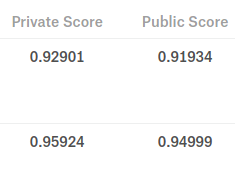

Resultados dos modelos: ‘gbm’ acima e ‘lm’ abaixo

Os dois modelos foram capazes de efetuar previsões sobre os dados, porém com uma taxa de erros muito maior que o observado durante a fase de teste.

Ambos modelos apresentaram uma performance pior no score privado, sugerindo que este modelo não obteve capacidade de generalização quando confrontado com dados inéditos.

Este trabalho ainda pode ser aperfeiçoado das seguintes formas:

- Reiniciar a análise exploratória em busca de novas features;
- Selecionar um volume maior de dados, possivelmente abrangendo todos períodos observados;
- Testar outros modelos preditivos.